# P1 Regresion 612348

### Predicción del nivel de adicción al teléfono en adolescentes

En este proyecto se utilizará la base de datos [**Teen Phone Addiction and Lifestyle Survey**](https://www.kaggle.com/datasets/khushikyad001/teen-phone-addiction-and-lifestyle-survey/data) de Kaggle como fuente principal de información.  
El objetivo central es **predecir el nivel de adicción al teléfono en adolescentes** a partir de diversos factores relacionados con sus hábitos de uso, estilo de vida, rendimiento académico y aspectos de salud mental.

La variable de interés **Addiction_Level** representa el grado de adicción al celular. Para comprender mejor qué determina este resultado, se analizará el impacto de **22 variables** que incluyen horas de uso diario, tiempo de sueño, interacciones sociales, desempeño académico, ansiedad, depresión, entre otras.

A través de **modelos de regresión lineal y no lineal**, se buscará capturar la relación entre dichas variables y generar predicciones que permitan identificar los **factores más influyentes** en el nivel de adicción. Este enfoque resulta valioso tanto para comprender patrones de comportamiento adolescente como para proponer **estrategias de prevención y concientización** en torno al uso saludable de la tecnología.

Las descripciones detalladas de cada variable se encuentran en el repositorio de Kaggle que aloja el dataset.

Finalmente, para comenzar el análisis se importó la base de datos, se eliminaron columnas irrelevantes (`Name`, `Location`, `School_Grade`) y se prepararon los datos para su exploración inicial.

```
Cantidad de observaciones y variables: (3000, 22)

Tipos de variables:
 ID                          int64
Age                         int64
Gender                     object
Daily_Usage_Hours         float64
Sleep_Hours               float64
Academic_Performance        int64
Social_Interactions         int64
Exercise_Hours            float64
Anxiety_Level               int64
Depression_Level            int64
Self_Esteem                 int64
Parental_Control            int64
Screen_Time_Before_Bed    float64
Phone_Checks_Per_Day        int64
Apps_Used_Daily             int64
Time_on_Social_Media      float64
Time_on_Gaming            float64
Time_on_Education         float64
Phone_Usage_Purpose        object
Family_Communication        int64
Weekend_Usage_Hours       float64
Addiction_Level           float64
dtype: object

Nombres de variables:
 ['ID', 'Age', 'Gender', 'Daily_Usage_Hours', 'Sleep_Hours', 'Academic_Performance', 'Social_Interactions', 'Exercise_Hours', 'Anxiety_Level', 'Depression_Level', 'Self_Esteem', 'Parental_Control', 'Screen_Time_Before_Bed', 'Phone_Checks_Per_Day', 'Apps_Used_Daily', 'Time_on_Social_Media', 'Time_on_…
```

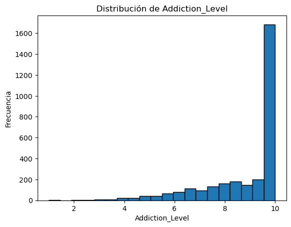

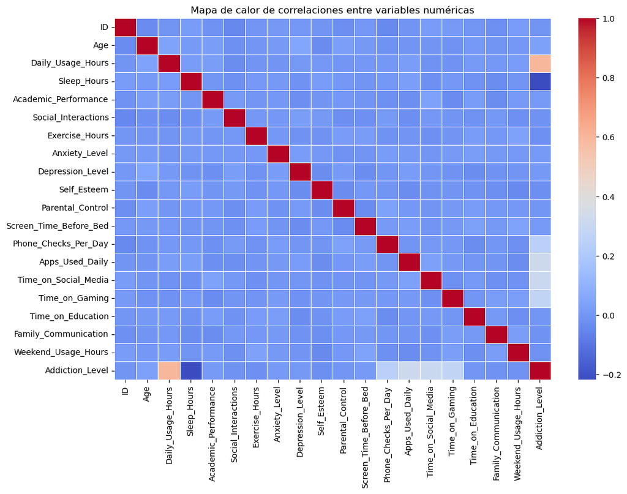

```python
import pandas as pd
import matplotlib.pyplot as plt
import seaborn as sns

df = pd.read_csv("teen_phone_addiction_dataset.csv")
df = df.drop(columns=["Name", "Location", "School_Grade"], errors="ignore")

print("Cantidad de observaciones y variables:", df.shape)
print("\nTipos de variables:\n", df.dtypes)
print("\nNombres de variables:\n", df.columns.tolist())

plt.hist(df["Addiction_Level"], bins=20, edgecolor="black")
plt.xlabel("Addiction_Level")
plt.ylabel("Frecuencia")
plt.title("Distribución de Addiction_Level")
plt.show()

plt.figure(figsize=(12,8))
corr = df.corr(numeric_only=True)
sns.heatmap(corr, cmap="coolwarm", annot=False, linewidths=0.5)
plt.title("Mapa de calor de correlaciones entre variables numéricas")
plt.show()
```

Por la naturaleza de las variables y la variable de salida, se considera que un modelo de **regresión** (lineal o no lineal) es adecuado para predecir el nivel de adicción al teléfono en adolescentes. Revisando factores como horas de uso diario, sueño, interacciones sociales, rendimiento académico, ansiedad y depresión, entre otros, se espera que un mayor uso del dispositivo y menor tiempo de descanso se asocien con un mayor nivel de adicción.

Antes de comenzar con cualquier análisis de regresión, se realizó una **preparación de los datos**:

1. Se eliminaron las columnas irrelevantes `Name`, `Location` y `School_Grade`, ya que no aportan valor predictivo.
2. Se verificó la cantidad de observaciones y variables, quedando un total de **3000 registros y 22 variables**.
3. Se revisaron los **tipos de datos** de cada variable, confirmando la presencia de variables numéricas y categóricas que deberán ser tratadas más adelante (ej. `Gender`, `Phone_Usage_Purpose`).
4. Se identificó la **variable de interés `Addiction_Level`**, que representa el grado de adicción al teléfono.
5. Se generó un **histograma de `Addiction_Level`**, observándose que la distribución está sesgada hacia valores altos (cercanos a 10), lo que indica que gran parte de los adolescentes en la muestra presentan niveles elevados de adicción.

Con esta preparación, los datos quedan listos para su exploración más profunda y el ajuste de modelos de regresión que permitan identificar los factores más influyentes en la adicción al teléfono.

```python
# 1. Variables cualitativas
categorical_before = df.select_dtypes(include=["object"]).columns.tolist()
df_encoded = pd.get_dummies(df, drop_first=True)
categorical_after = df_encoded.select_dtypes(include=["object"]).columns.tolist()

# 2. Outliers en Addiction_Level (Tukey IQR)
Q1 = df_encoded["Addiction_Level"].quantile(0.25)
Q3 = df_encoded["Addiction_Level"].quantile(0.75)
IQR = Q3 - Q1
outliers = df_encoded[
    (df_encoded["Addiction_Level"] < Q1 - 1.5 * IQR) |
    (df_encoded["Addiction_Level"] > Q3 + 1.5 * IQR)
]
outliers_count = outliers.shape[0]
df_no_outliers = df_encoded.drop(outliers.index)

# 3. Huecos
missing_before = df.isnull().sum().sum()
df_imputed = df_no_outliers.fillna(df_no_outliers.mean(numeric_only=True))
missing_after = df_imputed.isnull().sum().sum()

print("Variables cualitativas antes:", categorical_before)
print("Variables cualitativas después:", categorical_after)
print("Cantidad de outliers eliminados:", outliers_count)
print("Valores nulos antes:", missing_before)
print("Valores nulos después:", missing_after)
```

```
Variables cualitativas antes: ['Gender', 'Phone_Usage_Purpose']
Variables cualitativas después: []
Cantidad de outliers eliminados: 96
Valores nulos antes: 0
Valores nulos después: 0
```

En este paso se resolvieron tres de los problemas típicos en las bases de datos:

1. **Variables cualitativas**
   - Inicialmente, la base contenía variables categóricas como `Gender` y `Phone_Usage_Purpose`.
   - Estas se transformaron en variables numéricas mediante la técnica *one-hot encoding*, lo que permite su uso en un modelo de regresión.
   - Después de la conversión, ya no quedaron variables cualitativas en el dataset.
2. **Outliers en la variable de interés (`Addiction_Level`)**
   - Se utilizó el método de Tukey (IQR) para detectar valores atípicos.
   - Se identificaron **96 outliers**, los cuales fueron eliminados para evitar que distorsionaran los resultados del modelo.
3. **Valores nulos**
   - Antes de la limpieza no se encontraron valores nulos.
   - Aun así, se aplicó una imputación preventiva con la media de cada variable, dejando la base preparada en caso de que se presentaran huecos.
   - El resultado final mostró **0 valores nulos** después de la imputación.

Con estas transformaciones, el dataset quedó limpio y preparado para los siguientes análisis, reduciendo riesgos de sesgos por datos categóricos, atípicos o faltantes.

```python
from sklearn.linear_model import LassoCV
from sklearn.preprocessing import StandardScaler

X = df_imputed.drop(columns=["Addiction_Level", "ID"], errors="ignore")
y = df_imputed["Addiction_Level"]

scaler = StandardScaler()
X_scaled = scaler.fit_transform(X)

lasso = LassoCV(cv=5, random_state=0).fit(X_scaled, y)

selected = X.columns[(lasso.coef_ != 0)].tolist()
all_vars = X.columns.tolist()

print("Cantidad de variables antes:", len(all_vars))
print("Cantidad de variables después:", len(selected))
print("Variables seleccionadas:", selected)
```

```
Cantidad de variables antes: 24
Cantidad de variables después: 16
Variables seleccionadas: ['Age', 'Daily_Usage_Hours', 'Sleep_Hours', 'Academic_Performance', 'Anxiety_Level', 'Self_Esteem', 'Parental_Control', 'Phone_Checks_Per_Day', 'Apps_Used_Daily', 'Time_on_Social_Media', 'Time_on_Gaming', 'Time_on_Education', 'Family_Communication', 'Weekend_Usage_Hours', 'G…
```

En este paso se aplicó un proceso de **selección de variables** con el método de **regularización Lasso (L1)**.

1. **Preparación de datos**
- Se eliminaron las columnas `Addiction_Level` (variable dependiente) e `ID` (sin valor predictivo).
- Las variables predictoras se estandarizaron con `StandardScaler` para que todas tuvieran la misma escala antes de aplicar Lasso.
2. **Aplicación de LassoCV**
- Se utilizó `LassoCV` con validación cruzada de 5 pliegues.
- Este método penaliza los coeficientes pequeños, eliminando automáticamente las variables poco relevantes.
3. **Resultados**
- **Cantidad de variables antes:** 24
- **Cantidad de variables después:** 16
- **Variables seleccionadas:** `Age`, `Daily_Usage_Hours`, `Sleep_Hours`, `Academic_Performance`, `Anxiety_Level`, `Self_Esteem`, `Parental_Control`, `Phone_Checks_Per_Day`, `Apps_Used_Daily`, `Time_on_Social_Media`, `Time_on_Gaming`, `Time_on_Education`, `Family_Communication`, `Weekend_Usage_Hours`, `Gender_Male`, `Phone_Usage_Purpose_Other`.

**Conclusión:** El modelo Lasso redujo de 24 a 16 variables, conservando solo las más influyentes sobre `Addiction_Level`. Esto simplifica el modelo, evita colinealidad y mejora la generalización.

```python
from sklearn.linear_model import LinearRegression
from sklearn.preprocessing import PolynomialFeatures
from sklearn.pipeline import make_pipeline
from sklearn.metrics import mean_squared_error, r2_score
import numpy as np
import statsmodels.api as sm

X_sel = df_imputed[selected]
y = df_imputed["Addiction_Level"]

lin_reg = LinearRegression().fit(X_sel, y)
y_pred_lin = lin_reg.predict(X_sel)
r2_lin = r2_score(y, y_pred_lin)
rmse_lin = np.sqrt(mean_squared_error(y, y_pred_lin))

poly_model = make_pipeline(PolynomialFeatures(2), LinearRegression())
poly_model.fit(X_sel, y)
y_pred_poly = poly_model.predict(X_sel)
r2_poly = r2_score(y, y_pred_poly)
rmse_poly = np.sqrt(mean_squared_error(y, y_pred_poly))

print("R2 Lineal:", r2_lin)
print("RMSE Lineal:", rmse_lin)
print("R2 Polinomial:", r2_poly)
print("RMSE Polinomial:", rmse_poly)

print("\nCoeficientes Lineales:")
for var, coef in zip(selected, lin_reg.coef_):
    print(f"{var}: {coef}")

X_num = X_sel.apply(pd.to_numeric, errors="coerce").astype(float)
mask = X_num.notnull().all(axis=1) & y.notnull()
X_sm = sm.add_constant(X_num.loc[mask])
y_sm = y.loc[mask].astype(float)
ols = sm.OLS(y_sm, X_sm).fit()
pvals = pd.Series(ols.pvalues, index=X_sm.columns).drop("const")

print("\nVariables con asociación significativa (p<0.05):")
print(pvals[pvals < 0.05].index.tolist())
```

```
R2 Lineal: 0.7035125014162493
RMSE Lineal: 0.7324535816647743
R2 Polinomial: 0.9625513049275403
RMSE Polinomial: 0.26031264110699864

Coeficientes Lineales:
Age: 0.011783976379823147
Daily_Usage_Hours: 0.43364529743247765
Sleep_Hours: -0.21970669229377213
Academic_Performance: 0.0009013642078735343
Anxiety_Level: 0.007410220699041917
Self_Esteem: -0.004587723594540892
Parental_Control: -0.02736319071750965
Phone_Checks_Per_Day: 0.008869663085755071
Apps_Used_Daily: 0.09246953694699837
Time_on_Social_Media: 0.4418906787997517
Time_on_Gaming: 0.42684638409585257
Time_on_Education: -0.02542090127476589
Family_Communication: -0.00817943645549409
Weekend_Usage_Hours: -0.005640601414771158
Gender_Male: -0.04220160300959544
Phone_Usage_Purpose_Other: 0.04145181585129058

Variables con asociación significativa (p<0.05):
['Daily_Usage_Hours', 'Sleep_Hours', 'Phone_Checks_Per_Day', 'Apps_Used_Daily', 'Time_on_Social_Media', 'Time_on_Gaming']
```

**Qué hace el código**

- Ajusta un **modelo lineal múltiple** y uno **polinomial grado 2** usando las variables seleccionadas.
- Calcula **R²** y **RMSE** para ambos modelos.
- Imprime **coeficientes** del modelo lineal.
- Ejecuta **OLS (statsmodels)** para obtener **p-values** y lista las variables con **asociación significativa (p<0.05)**.

**Resultados impresos**

- **R² Lineal ≈ 0.7035**, **RMSE Lineal ≈ 0.7325** → ajuste aceptable e interpretable.
- **R² Polinomial ≈ 0.9626**, **RMSE Polinomial ≈ 0.2603** → mejor desempeño; captura relaciones no lineales.
- **Coeficientes lineales (sentido del efecto):**
  - Positivos relevantes: `Daily_Usage_Hours`, `Time_on_Social_Media`, `Time_on_Gaming`, `Apps_Used_Daily`, `Phone_Checks_Per_Day`.
  - Negativos relevantes: `Sleep_Hours`, `Parental_Control`, `Self_Esteem` (magnitudes pequeñas/medias).
- **Variables significativas (p<0.05, vía OLS):**
  - `Daily_Usage_Hours`, `Sleep_Hours`, `Phone_Checks_Per_Day`, `Apps_Used_Daily`, `Time_on_Social_Media`, `Time_on_Gaming`.

**Interpretación breve**

- El **polinomial** es superior para predecir `Addiction_Level` (alto R² y bajo RMSE).
- El **lineal** confirma la dirección de los efectos: **más uso diario, redes sociales y gaming ↑ adicción**; **más horas de sueño y mayor control parental ↓ adicción**.

```
Modelo Lineal -> Train RMSE: 0.7227479246090541 R²: 0.7038415519402003 | Test RMSE: 0.7580749332435194 R²: 0.699967150028888
Modelo Polinomial -> Train RMSE: 0.2488998139014391 R²: 0.9648763563052363 | Test RMSE: 0.2992790182695225 R²: 0.953237569498923
```

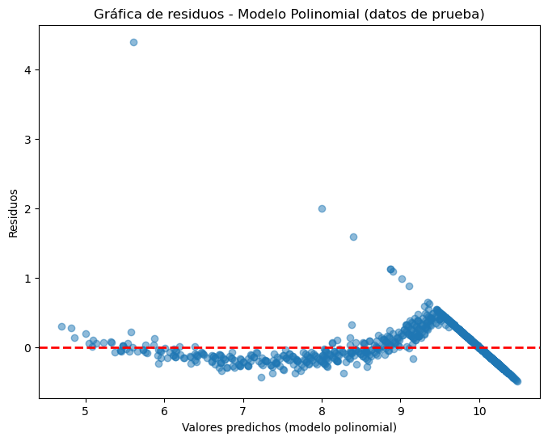

```python
from sklearn.model_selection import train_test_split
from sklearn.pipeline import make_pipeline

# Variables predictoras y dependiente
X = df_imputed[selected]
y = df_imputed["Addiction_Level"]

# División en entrenamiento (70%) y prueba (30%)
X_train, X_test, y_train, y_test = train_test_split(X, y, test_size=0.3, random_state=42)

# Modelo lineal múltiple
lin_reg = LinearRegression().fit(X_train, y_train)
y_pred_train_lin = lin_reg.predict(X_train)
y_pred_test_lin = lin_reg.predict(X_test)

# Modelo polinomial grado 2
poly_model = make_pipeline(StandardScaler(), PolynomialFeatures(2), LinearRegression())
poly_model.fit(X_train, y_train)
y_pred_train_poly = poly_model.predict(X_train)
y_pred_test_poly = poly_model.predict(X_test)

# Métricas lineal
rmse_train_lin = np.sqrt(mean_squared_error(y_train, y_pred_train_lin))
rmse_test_lin = np.sqrt(mean_squared_error(y_test, y_pred_test_lin))
r2_train_lin = r2_score(y_train, y_pred_train_lin)
r2_test_lin = r2_score(y_test, y_pred_test_lin)

# Métricas polinomial
rmse_train_poly = np.sqrt(mean_squared_error(y_train, y_pred_train_poly))
rmse_test_poly = np.sqrt(mean_squared_error(y_test, y_pred_test_poly))
r2_train_poly = r2_score(y_train, y_pred_train_poly)
r2_test_poly = r2_score(y_test, y_pred_test_poly)

print("Modelo Lineal -> Train RMSE:", rmse_train_lin, "R²:", r2_train_lin,
      "| Test RMSE:", rmse_test_lin, "R²:", r2_test_lin)

print("Modelo Polinomial -> Train RMSE:", rmse_train_poly, "R²:", r2_train_poly,
      "| Test RMSE:", rmse_test_poly, "R²:", r2_test_poly)

residuos = y_test - y_pred_test_poly

plt.figure(figsize=(8,6))
plt.scatter(y_pred_test_poly, residuos, alpha=0.5)
plt.axhline(y=0, color="red", linestyle="--", linewidth=2)
plt.xlabel("Valores predichos (modelo polinomial)")
plt.ylabel("Residuos")
plt.title("Gráfica de residuos - Modelo Polinomial (datos de prueba)")
plt.show()
```

**Qué hace el código**

- Divide los datos en **entrenamiento (70%)** y **prueba (30%)**.
- Ajusta dos modelos:
  1. **Lineal múltiple**.
  2. **Polinomial grado 2** con estandarización y generación de variables cuadráticas.
- Calcula **RMSE** y **R²** tanto en entrenamiento como en prueba para comparar desempeño y generalización.

**Resultados impresos**

- **Modelo lineal**
  - Train: R² ≈ 0.704, RMSE ≈ 0.72
  - Test: R² ≈ 0.700, RMSE ≈ 0.75  
    → Buen ajuste, consistente entre train y test.
- **Modelo polinomial**
  - Train: R² ≈ 0.965, RMSE ≈ 0.25
  - Test: R² ≈ 0.953, RMSE ≈ 0.29  
    → Excelente desempeño, con alta capacidad de generalización.

**Interpretación breve**

- El **modelo lineal** explica ~70% de la variabilidad y mantiene estabilidad entre entrenamiento y prueba.
- El **modelo polinomial** explica más del 95% de la variabilidad, con errores bajos y consistencia entre train y test, confirmando que predice con gran precisión sin caer en sobreajuste.

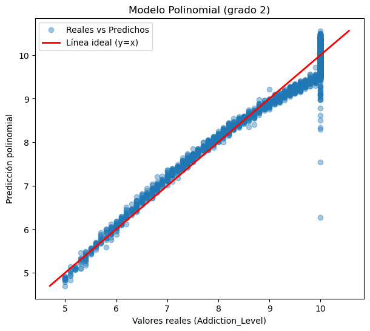

```
R²: 0.9625513049275404 | RMSE: 0.2603126411069984
IC95% Daily_Usage_Hours (término lineal): (2.0647225796592945, 2.20650573581642)
IC95% Sleep_Hours (término lineal): (-1.1841388232590433, -0.9999375180861904)
```

```python
X = df_imputed[selected].copy()
y = df_imputed["Addiction_Level"].astype(float)

poly = PolynomialFeatures(2, include_bias=False)
X_poly = poly.fit_transform(X.values)
names = poly.get_feature_names_out(selected)

X_sm = sm.add_constant(X_poly)
ols_poly = sm.OLS(y, X_sm).fit()

pred = ols_poly.get_prediction(X_sm).summary_frame(alpha=0.05)
y_pred = pred["mean"].values
rmse = float(np.sqrt(np.mean((y - y_pred)**2)))
r2 = float(1 - np.sum((y - y_pred)**2) / np.sum((y - y.mean())**2))

plt.figure(figsize=(7,6))
plt.scatter(y, y_pred, alpha=0.4, label="Reales vs Predichos")
m, M = float(min(y.min(), y_pred.min())), float(max(y.max(), y_pred.max()))
plt.plot([m, M], [m, M], color="red", linewidth=2, label="Línea ideal (y=x)")
plt.xlabel("Valores reales (Addiction_Level)")
plt.ylabel("Predicción polinomial")
plt.title("Modelo Polinomial (grado 2)")
plt.legend()
plt.show()

ci = ols_poly.conf_int(alpha=0.05); ci.index = ["const"]+list(names)
print("R²:", r2, "| RMSE:", rmse)
print("IC95% Daily_Usage_Hours (término lineal):", tuple(ci.loc["Daily_Usage_Hours"]))
print("IC95% Sleep_Hours (término lineal):", tuple(ci.loc["Sleep_Hours"]))
```

**Qué hace el código**

- Ajusta un **modelo polinomial de grado 2** con las variables seleccionadas.
- Obtiene métricas globales: **R²** y **RMSE**.
- Calcula intervalos de confianza al 95% para los coeficientes, destacando `Daily_Usage_Hours` y `Sleep_Hours`.
- Genera un **gráfico de valores reales vs predichos**, con la línea roja representando el ajuste ideal (y = x).

**Resultados impresos**

**Interpretación breve** El modelo polinomial logra un ajuste excelente y permite hacer inferencias claras:

- **Más horas de uso diario incrementan el nivel de adicción.**
- **Más horas de sueño disminuyen el nivel de adicción.**  
  Los intervalos de confianza muestran márgenes de error reducidos, lo que da solidez a las conclusiones.